# Project_PCA

Kikalova Tatiana

12/2/2021

## Task 1

• Unpack the archive with the data. There will be two files: the first contains information about the elemental composition of the substances, and the second contains all sorts of physical and chemical properties. • Combine these files into one table (do not include the material column in it, as we will not need it further). • In this task, we want to learn how to predict the critical temperature of a superconductor (column critical_temp) from various characteristics of the substance and its composition (all other columns).

```r
# install.packages("caret")
library(caret)
library(dplyr)
conducts1 <- read.csv(file = "train.csv", na.strings=c("NA", " ", ""))
conducts2 <- read.csv(file = "unique_m.csv", na.strings=c("NA", " ", ""))
conducts2 <- conducts2 %>% select(-He, -Ne, -Ar, -Kr, -Xe, -Pm, -Po, -At, -Rn) # remove "0" columns

result_file <- cbind(conducts1, conducts2)
result_file2 <- result_file[,1:(length(result_file)-2)] # remove duplicate of critical_temp and material column
```

## Task 2

• Divide the data into training and test samples, on the first you will evaluate the coefficients, on the second you will calculate the metric.

```r
result_file2$row_num <- seq.int(nrow(result_file2)) # Adding column with numbers of rows
```

```r
#split data into training and test
set.seed(234)

training.sample <- result_file2$row_num %>%
  createDataPartition(p = .8, list = FALSE)

train.data <- result_file2[training.sample, ]
test.data <- result_file2[-training.sample, ]
```

## Task 3

Standardize your data (but not the target variable). The important point is that you must calculate the mean and standard deviation of the training data, and then transform the test data with this mean and standard deviation. If it is not clear why, then imagine that you have received one test case.

```r
# names of variables I don't want to scale
varnames <- c("critical_temp", "row_num")

# index vector of columns which must not be scaled
index <- names(train.data) %in% varnames

# scale only the columns not in index
temp <- scale(train.data[, !index])
train.data[, !index] <- temp

# get the means and standard deviations from temp, to scale test too
means <- attr(temp, "scaled:center")
standard_deviations <- attr(temp, "scaled:scale")

# scale test
test.data[, !index] <- scale(test.data[, !index], center = means, scale = standard_deviations)
```

## Task 4

• Build a linear model that predicts the critical temperature for all the features you have, look at the adjusted R-squared. Was the model a good one?

```r
#Build Model
model <- lm(critical_temp ~., data = train.data)

# Adjusted R-squared:  0.7599
summary(model)
```

```
##
## Call:
## lm(formula = critical_temp ~ ., data = train.data)
##
## Residuals:
##     Min      1Q  Median      3Q     Max
## -99.183  -8.208   0.717  10.146 169.767
##
## Coefficients:
##                                   Estimate Std. Error t value Pr(>|t|)
## (Intercept)                      3.605e+01  4.199e-01  85.855  < 2e-16 ***
## number_of_elements               2.528e-01  1.196e+00   0.211 0.832611
## mean_atomic_mass                 2.442e+01  2.732e+00   8.939  < 2e-16 ***
## wtd_mean_atomic_mass            -3.946e+01  3.845e+00 -10.261  < 2e-16 ***
## gmean_atomic_mass               -1.149e+01  2.821e+00  -4.074 4.63e-05 ***
## wtd_gmean_atomic_mass            2.442e+01  3.968e+00   6.154 7.73e-10 ***
## entropy_atomic_mass             -8.073e+00  1.941e+00  -4.158 3.22e-05 ***
## wtd_entropy_atomic_mass          6.714e-01  1.654e+00   0.406 0.684823
## range_atomic_mass                1.035e+01  1.029e+00  10.060  < 2e-16 ***
## wtd_range_atomic_mass            2.961e+00  6.531e-01   4.534 5.83e-06 ***
## std_atomic_mass                 -9.591e+00  1.411e+00  -6.796 1.11e-11 ***
## wtd_std_atomic_mass             -6.024e-03  1.232e+00  -0.005 0.996099
## mean_fie                        -1.836e+01  6.470e+00  -2.838 0.004547 **
## wtd_mean_fie                     9.920e+00  1.270e+01   0.781 0.434737
## gmean_fie                        1.478e+01  5.741e+00   2.574 0.010053 *
## wtd_gmean_fie                   -2.769e+00  1.052e+01  -0.263 0.792307
## entropy_fie                     -1.145e+01  8.967e+00  -1.277 0.201719
## wtd_entropy_fie                  1.940e+01  1.845e+00  10.514  < 2e-16 ***
## range_fie                        1.644e+01  2.306e+00   7.128 1.06e-12 ***
## wtd_range_fie                    4.088e+00  9.051e-01   4.516 6.33e-06 ***
## std_fie                         -1.197e+01  2.837e+00  -4.217 2.49e-05 ***
## wtd_std_fie                     -5.044e+00  3.008e+00  -1.677 0.093651 .
## mean_atomic_radius              -1.367e+01  4.154e+00  -3.292 0.000998 ***
## wtd_mean_atomic_radius           5.933e+01  7.849e+00   7.559 4.27e-14 ***
## gmean_atomic_radius              9.253e+00  4.590e+00   2.016 0.043845 *
## wtd_gmean_atomic_radius         -6.392e+01  9.553e+00  -6.691 2.29e-11 ***
## entropy_atomic_radius           -3.844e+00  7.915e+00  -0.486 0.627217
## wtd_entropy_atomic_radius        1.001e+01  2.483e+00   4.033 5.53e-05 ***
## range_atomic_radius              3.452e+00  1.688e+00   2.045 0.040860 *
## wtd_range_atomic_radius         -2.110e+00  6.173e-01  -3.419 0.000630 ***
```

[output cut: 121 more lines]

```
## Os                               2.996e-01  1.525e-01   1.964 0.049564 *
## Ir                               3.192e-02  1.643e-01   0.194 0.845934
## Pt                               1.275e+00  1.980e-01   6.443 1.21e-10 ***
## Au                              -4.889e-01  1.833e-01  -2.668 0.007636 **
## Hg                               9.550e-01  1.879e-01   5.084 3.74e-07 ***
## Tl                               1.563e+00  1.619e-01   9.650  < 2e-16 ***
## Pb                               4.604e-01  1.494e-01   3.082 0.002058 **
## Bi                               4.054e+00  2.382e-01  17.019  < 2e-16 ***
## row_num                         -1.661e-04  3.760e-05  -4.417 1.01e-05 ***
## ---
## Signif. codes:  0 '***' 0.001 '**' 0.01 '*' 0.05 '.' 0.1 ' ' 1
##
## Residual standard error: 16.7 on 16851 degrees of freedom
## Multiple R-squared:  0.7622, Adjusted R-squared:  0.7599
## F-statistic: 339.6 on 159 and 16851 DF,  p-value: < 2.2e-16
```

```r
# predict using the Model
predictions <- model %>% predict(test.data)

compare <- data.frame(actual = test.data$critical_temp,
                      predicted = predictions)

error <- RMSE(predictions, test.data$critical_temp)
error
```

```
## [1] 28.01025
```

**Results:** In our case the model doesn’t look really good - as we can see the **Adjusted R-squared = 0.7599**, which is quite low.

## Task 5

• It seems that such a large number of features may prevent us from getting a better model. Let’s try to apply **PCA**. Attention, here you need to act carefully, as well as with standardization, you need to get the coefficients for the main components on the training data and then use this to transform the test data.

```r
#install.packages("vegan")
library(vegan)
# Principal Component Analysis:
train.data_pc <- prcomp(train.data, scale = TRUE)

#compute standard deviation of each principal component
std_dev <- train.data_pc$sdev

#compute variance
pr_var <- std_dev^2

#check variance of first 10 components
pr_var[1:10]
```

```
##  [1] 33.809990  9.195909  8.696398  6.832900  5.338457  3.530779  3.376178
##  [8]  2.911445  2.591464  2.399263
```

```r
#proportion of variance explained
prop_varex <- pr_var/sum(pr_var)
prop_varex[1:20]
```

```
##  [1] 0.211312439 0.057474429 0.054352488 0.042705624 0.033365354 0.022067370
##  [7] 0.021101114 0.018196531 0.016196652 0.014995392 0.013494368 0.012996968
## [13] 0.012007610 0.011319114 0.010918023 0.010697852 0.010464994 0.009921144
## [19] 0.009700873 0.009138395
```

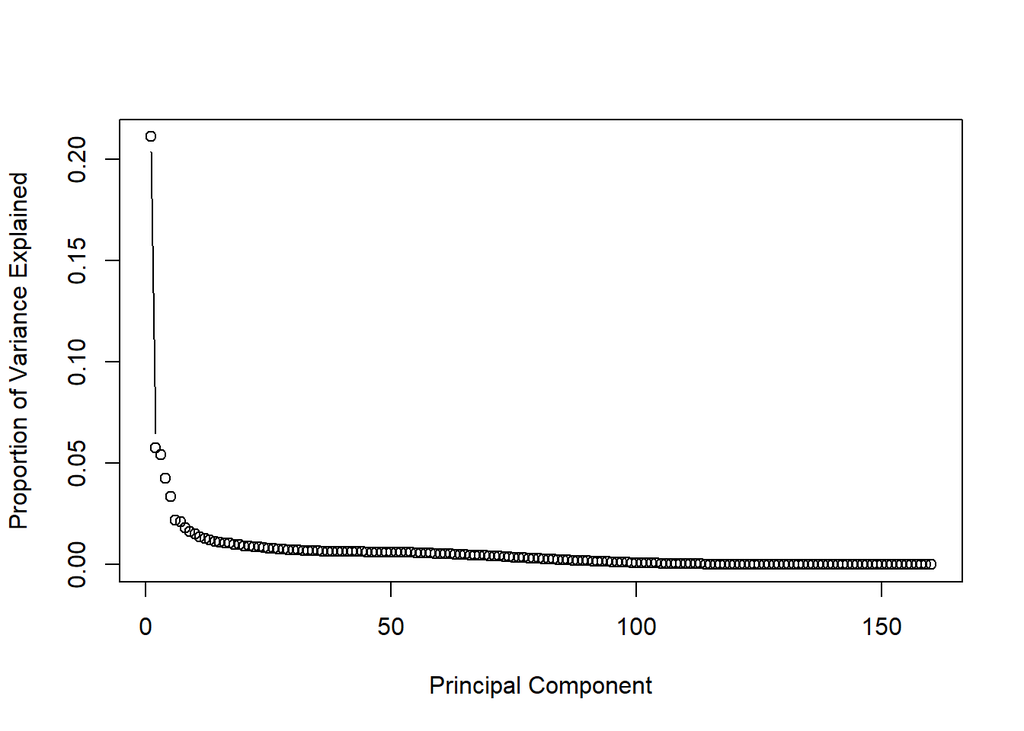

```r
#scree plot
plot(prop_varex, xlab = "Principal Component",
     ylab = "Proportion of Variance Explained",
     type = "b")
```

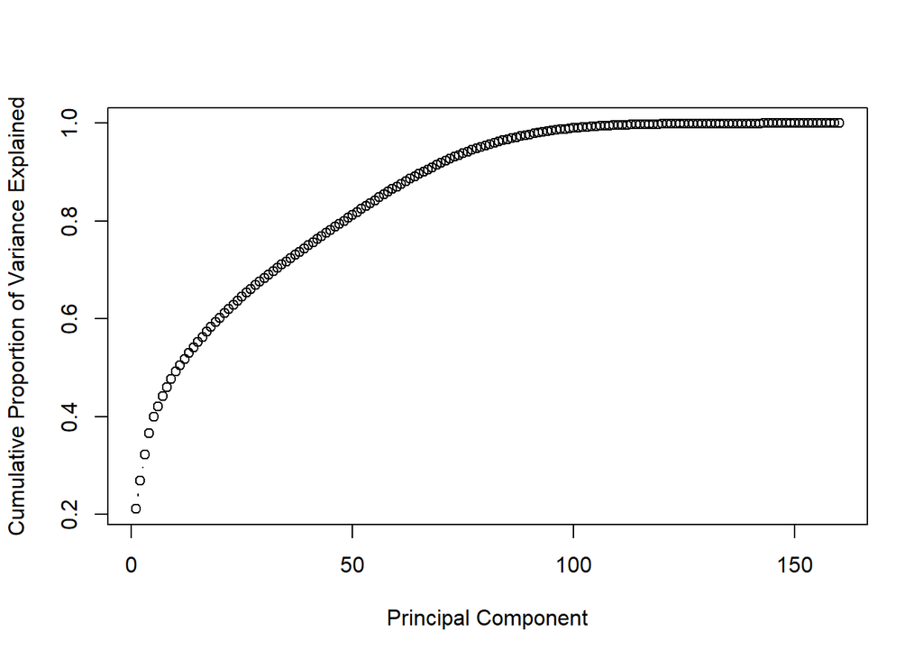

```r
#cumulative scree plot
plot(cumsum(prop_varex), xlab = "Principal Component",
       ylab = "Cumulative Proportion of Variance Explained",
       type = "b")
```

```r
eigenvals(train.data_pc)
```

```
##      PC1      PC2      PC3      PC4      PC5      PC6      PC7      PC8
## 33.80999  9.19591  8.69640  6.83290  5.33846  3.53078  3.37618  2.91144
##      PC9     PC10     PC11     PC12     PC13     PC14     PC15     PC16
##  2.59146  2.39926  2.15910  2.07951  1.92122  1.81106  1.74688  1.71166
##     PC17     PC18     PC19     PC20     PC21     PC22     PC23     PC24
##  1.67440  1.58738  1.55214  1.46214  1.43962  1.39527  1.37590  1.33733
##     PC25     PC26     PC27     PC28     PC29     PC30     PC31     PC32
##  1.28884  1.27835  1.24474  1.22243  1.16692  1.14901  1.13507  1.11421
##     PC33     PC34     PC35     PC36     PC37     PC38     PC39     PC40
##  1.10630  1.09271  1.06798  1.05257  1.04713  1.04006  1.03645  1.03199
##     PC41     PC42     PC43     PC44     PC45     PC46     PC47     PC48
##  1.02128  1.01233  1.00896  1.00793  1.00247  0.99901  0.99650  0.99131
##     PC49     PC50     PC51     PC52     PC53     PC54     PC55     PC56
##  0.98757  0.98195  0.97671  0.96464  0.96044  0.94941  0.94370  0.92951
##     PC57     PC58     PC59     PC60     PC61     PC62     PC63     PC64
##  0.91722  0.88616  0.87872  0.87354  0.84717  0.83471  0.82119  0.79356
##     PC65     PC66     PC67     PC68     PC69     PC70     PC71     PC72
##  0.77980  0.76292  0.73897  0.72488  0.71261  0.69618  0.67304  0.66221
##     PC73     PC74     PC75     PC76     PC77     PC78     PC79     PC80
##  0.62655  0.59807  0.57768  0.56734  0.52525  0.50894  0.48817  0.46881
##     PC81     PC82     PC83     PC84     PC85     PC86     PC87     PC88
##  0.45315  0.44300  0.41704  0.38251  0.36180  0.35215  0.32812  0.32016
##     PC89     PC90     PC91     PC92     PC93     PC94     PC95     PC96
##  0.30667  0.29710  0.27603  0.26965  0.23138  0.22618  0.21332  0.19780
##     PC97     PC98     PC99    PC100    PC101    PC102    PC103    PC104
##  0.18816  0.17381  0.16160  0.15399  0.12347  0.11360  0.11145  0.10540
##    PC105    PC106    PC107    PC108    PC109    PC110    PC111    PC112
##  0.09636  0.09386  0.07608  0.07103  0.06088  0.05921  0.05674  0.05479
##    PC113    PC114    PC115    PC116    PC117    PC118    PC119    PC120
##  0.04827  0.03985  0.03795  0.03665  0.03156  0.03030  0.02594  0.02200
##    PC121    PC122    PC123    PC124    PC125    PC126    PC127    PC128
##  0.01974  0.01793  0.01667  0.01542  0.01488  0.01358  0.01321  0.01243
##    PC129    PC130    PC131    PC132    PC133    PC134    PC135    PC136
##  0.01216  0.01067  0.01035  0.00889  0.00785  0.00740  0.00676  0.00611
##    PC137    PC138    PC139    PC140    PC141    PC142    PC143    PC144
##  0.00562  0.00554  0.00495  0.00450  0.00381  0.00335  0.00299  0.00261
##    PC145    PC146    PC147    PC148    PC149    PC150    PC151    PC152
##  0.00247  0.00210  0.00201  0.00153  0.00132  0.00128  0.00116  0.00105
##    PC153    PC154    PC155    PC156    PC157    PC158    PC159    PC160
##  0.00060  0.00045  0.00038  0.00028  0.00015  0.00010  0.00007  0.00004
```

```r
#let's check broken stick plot
bstick(train.data_pc)
```

```
##        PC1        PC2        PC3        PC4        PC5        PC6        PC7
## 5.65551122 4.65551122 4.15551122 3.82217789 3.57217789 3.37217789 3.20551122
##        PC8        PC9       PC10       PC11       PC12       PC13       PC14
## 3.06265408 2.93765408 2.82654297 2.72654297 2.63563388 2.55230055 2.47537747
##       PC15       PC16       PC17       PC18       PC19       PC20       PC21
## 2.40394890 2.33728223 2.27478223 2.21595870 2.16040315 2.10777157 2.05777157
##       PC22       PC23       PC24       PC25       PC26       PC27       PC28
## 2.01015252 1.96469797 1.92121971 1.87955305 1.83955305 1.80109151 1.76405447
##       PC29       PC30       PC31       PC32       PC33       PC34       PC35
## 1.72834019 1.69385743 1.66052409 1.62826603 1.59701603 1.56671300 1.53730123
##       PC36       PC37       PC38       PC39       PC40       PC41       PC42
## 1.50872981 1.48095203 1.45392500 1.42760921 1.40196819 1.37696819 1.35257794
##       PC43       PC44       PC45       PC46       PC47       PC48       PC49
## 1.32876842 1.30551260 1.28278533 1.26056311 1.23882398 1.21754738 1.19671405
##       PC50       PC51       PC52       PC53       PC54       PC55       PC56
## 1.17630589 1.15630589 1.13669804 1.11746727 1.09859935 1.08008083 1.06189901
##       PC57       PC58       PC59       PC60       PC61       PC62       PC63
## 1.04404187 1.02649801 1.00925663 0.99230748 0.97564081 0.95924737 0.94311834
##       PC64       PC65       PC66       PC67       PC68       PC69       PC70
## 0.92724532 0.91162032 0.89623571 0.88108419 0.86615882 0.85145294 0.83696018
##       PC71       PC72       PC73       PC74       PC75       PC76       PC77
## 0.82267447 0.80858996 0.79470107 0.78100244 0.76748893 0.75415559 0.74099770
##       PC78       PC79       PC80       PC81       PC82       PC83       PC84
## 0.72801069 0.71519017 0.70253195 0.69003195 0.67768627 0.66549115 0.65344295
##       PC85       PC86       PC87       PC88       PC89       PC90       PC91
## 0.64153819 0.62977348 0.61814558 0.60665132 0.59528769 0.58405173 0.57294062
##       PC92       PC93       PC94       PC95       PC96       PC97       PC98
## 0.56195161 0.55108205 0.54032936 0.52969106 0.51916474 0.50874808 0.49843880
##       PC99      PC100      PC101      PC102      PC103      PC104      PC105
## 0.48823472 0.47813371 0.46813371 0.45823272 0.44842880 0.43872006 0.42910467
##      PC106      PC107      PC108      PC109      PC110      PC111      PC112
## 0.41958086 0.41014690 0.40080111 0.39154185 0.38236754 0.37327663 0.36426762
##      PC113      PC114      PC115      PC116      PC117      PC118      PC119
## 0.35533905 0.34648949 0.33771756 0.32902191 0.32040122 0.31185421 0.30337963
##      PC120      PC121      PC122      PC123      PC124      PC125      PC126
## 0.29497627 0.28664294 0.27837847 0.27018175 0.26205167 0.25398716 0.24598716
##      PC127      PC128      PC129      PC130      PC131      PC132      PC133
## 0.23805065 0.23017663 0.22236413 0.21461219 0.20691989 0.19928630 0.19171054
##      PC134      PC135      PC136      PC137      PC138      PC139      PC140
## 0.18419174 0.17672906 0.16932165 0.16196871 0.15466944 0.14742306 0.14022882
##      PC141      PC142      PC143      PC144      PC145      PC146      PC147
## 0.13308596 0.12599376 0.11895151 0.11195850 0.10501406 0.09811751 0.09126819
##      PC148      PC149      PC150      PC151      PC152      PC153      PC154
## 0.08446547 0.07770871 0.07099730 0.06433064 0.05770812 0.05112917 0.04459322
##      PC155      PC156      PC157      PC158      PC159      PC160
## 0.03809972 0.03164811 0.02523785 0.01886842 0.01253931 0.00625000
```

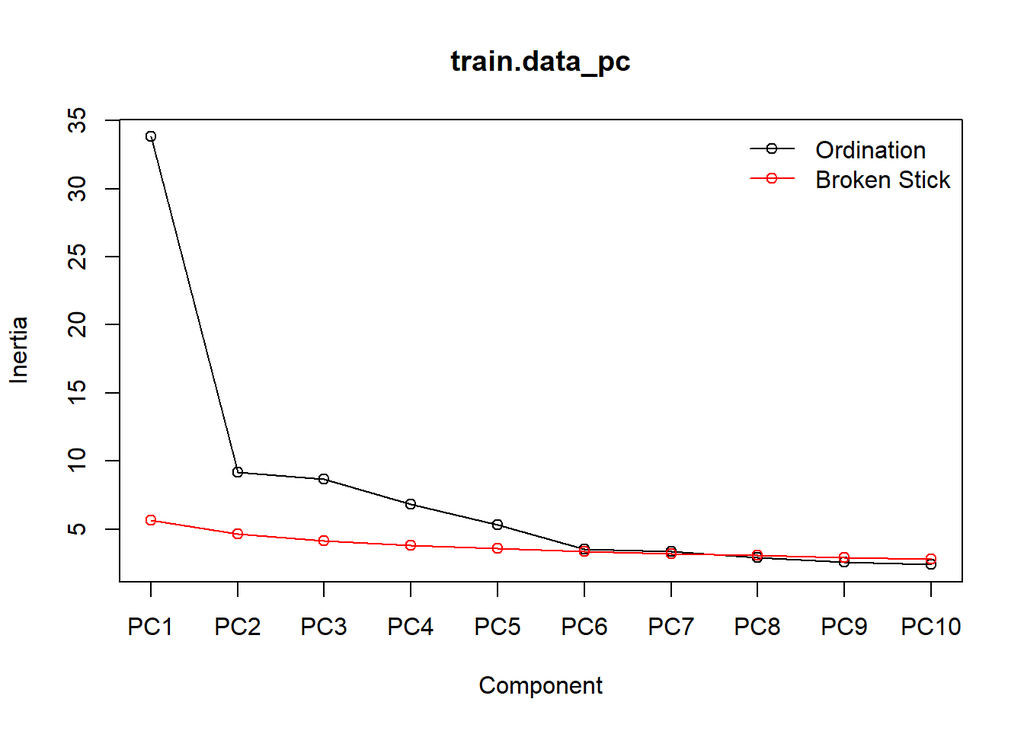

```r
screeplot(train.data_pc, type = "lines", bstick = TRUE)
```

## Task 6

• Choose the optimal number of main components in your opinion and build a new model with their help. Has the model gotten better?

```r
# Round 1:if we will take 6 main PCs and add to target variable from train.data:
pca_scores <- scores(train.data_pc, display = "species", choices = c(1:6), scaling = 0)
train.data_1 <- as.matrix(train.data) %*% pca_scores
train.data_1 <- as.data.frame(train.data_1)
train.data_comb_1 <- cbind(train.data_1, train.data$critical_temp)
colnames(train.data_comb_1)[7] <- "critical_temp"


model_1 <- lm(formula = critical_temp ~ ., data = train.data_comb_1)

# Adjusted R-squared: 0.8102
summary(model_1)
```

```
##
## Call:
## lm(formula = critical_temp ~ ., data = train.data_comb_1)
##
## Residuals:
##     Min      1Q  Median      3Q     Max
## -53.502  -9.956  -0.994  10.246  87.500
##
## Coefficients:
##             Estimate Std. Error t value Pr(>|t|)
## (Intercept) 29.16136    0.30059   97.01   <2e-16 ***
## PC1          1.31973    0.02167   60.90   <2e-16 ***
## PC2          0.41794    0.03500   11.94   <2e-16 ***
## PC3         -1.81101    0.02905  -62.34   <2e-16 ***
## PC4          2.43438    0.04014   60.65   <2e-16 ***
## PC5          1.17147    0.03978   29.45   <2e-16 ***
## PC6         -4.15979    0.04808  -86.51   <2e-16 ***
## ---
## Signif. codes:  0 '***' 0.001 '**' 0.01 '*' 0.05 '.' 0.1 ' ' 1
##
## Residual standard error: 14.85 on 17004 degrees of freedom
## Multiple R-squared:  0.8103, Adjusted R-squared:  0.8102
## F-statistic: 1.21e+04 on 6 and 17004 DF,  p-value: < 2.2e-16
```

```r
test.data_1 <- as.matrix(test.data) %*% pca_scores
test.data_1 <- as.data.frame(test.data_1)
test.data_comb_1 <- cbind(test.data_1, test.data$critical_temp)
colnames(test.data_comb_1)[7] <- "critical_temp"

# predict using the Model
predictions_1 <- model_1 %>% predict(test.data_comb_1)

compare_1 <- data.frame(actual = test.data_comb_1$critical_temp,
                      predicted = predictions_1)

error_1 <- RMSE(predictions_1, test.data_comb_1$critical_temp)
error_1
```

```
## [1] 15.55186
```

```r
# Round 2: if we will take ALL PCs and add to a target variable from train.data:
pca_scores2 <- scores(train.data_pc, display = "species", scaling = 0)
train.data_2 <- as.matrix(train.data) %*% pca_scores2
train.data_2 <- as.data.frame(train.data_2)
train.data_comb_2 <- cbind(train.data_2, train.data$critical_temp)
colnames(train.data_comb_2)[161] <- "critical_temp"


model2 <- lm(critical_temp ~ ., data = train.data_comb_2)

# Adjusted R-squared: 1
summary(model2)
```

```
##
## Call:
## lm(formula = critical_temp ~ ., data = train.data_comb_2)
##
## Residuals:
##       Min        1Q    Median        3Q       Max
## -7.94e-12 -3.30e-13 -3.00e-14  2.50e-13  5.77e-10
##
## Coefficients:
##               Estimate Std. Error    t value Pr(>|t|)
## (Intercept)  1.199e-11  1.730e-13  6.933e+01   <2e-16 ***
## PC1          1.179e-01  1.490e-14  7.909e+12   <2e-16 ***
## PC2          7.239e-02  1.678e-14  4.313e+12   <2e-16 ***
## PC3          5.564e-02  1.818e-14  3.060e+12   <2e-16 ***
## PC4          4.169e-02  1.722e-14  2.420e+12   <2e-16 ***
## PC5         -6.617e-02  2.109e-14 -3.138e+12   <2e-16 ***
## PC6         -9.736e-02  2.491e-14 -3.908e+12   <2e-16 ***
## PC7         -2.621e-02  2.405e-14 -1.090e+12   <2e-16 ***
## PC8          2.545e-02  2.593e-14  9.813e+11   <2e-16 ***
## PC9          2.108e-02  2.782e-14  7.576e+11   <2e-16 ***
## PC10         4.381e-02  2.890e-14  1.516e+12   <2e-16 ***
## PC11         4.684e-02  3.025e-14  1.549e+12   <2e-16 ***
## PC12         7.287e-02  3.102e-14  2.349e+12   <2e-16 ***
## PC13         1.277e-01  3.358e-14  3.804e+12   <2e-16 ***
## PC14         4.413e-02  3.298e-14  1.338e+12   <2e-16 ***
## PC15        -1.976e-02  3.347e-14 -5.903e+11   <2e-16 ***
## PC16        -4.679e-02  3.389e-14 -1.381e+12   <2e-16 ***
## PC17         2.880e-02  3.408e-14  8.449e+11   <2e-16 ***
## PC18         3.463e-02  3.504e-14  9.881e+11   <2e-16 ***
## PC19        -5.334e-03  3.543e-14 -1.505e+11   <2e-16 ***
## PC20        -9.226e-03  3.640e-14 -2.534e+11   <2e-16 ***
## PC21        -8.640e-02  3.732e-14 -2.315e+12   <2e-16 ***
## PC22        -1.026e-02  3.753e-14 -2.735e+11   <2e-16 ***
## PC23        -1.547e-02  3.769e-14 -4.105e+11   <2e-16 ***
## PC24         2.370e-02  3.809e-14  6.221e+11   <2e-16 ***
## PC25         3.016e-02  3.905e-14  7.724e+11   <2e-16 ***
## PC26         3.935e-02  3.902e-14  1.008e+12   <2e-16 ***
## PC27        -1.398e-02  3.952e-14 -3.537e+11   <2e-16 ***
## PC28         1.830e-02  3.983e-14  4.594e+11   <2e-16 ***
## PC29         4.934e-02  4.090e-14  1.206e+12   <2e-16 ***
```

[output cut: 122 more lines]

```
## PC152        3.684e-03  1.357e-12  2.715e+09   <2e-16 ***
## PC153       -2.031e-03  1.800e-12 -1.129e+09   <2e-16 ***
## PC154        9.729e-04  2.070e-12  4.701e+08   <2e-16 ***
## PC155       -2.567e-03  2.253e-12 -1.139e+09   <2e-16 ***
## PC156        8.289e-04  2.646e-12  3.133e+08   <2e-16 ***
## PC157       -3.534e-04  3.539e-12 -9.984e+07   <2e-16 ***
## PC158        1.122e-03  4.327e-12  2.592e+08   <2e-16 ***
## PC159        3.176e-04  5.438e-12  5.841e+07   <2e-16 ***
## PC160       -1.176e-04  6.694e-12 -1.757e+07   <2e-16 ***
## ---
## Signif. codes:  0 '***' 0.001 '**' 0.01 '*' 0.05 '.' 0.1 ' ' 1
##
## Residual standard error: 5.74e-12 on 16850 degrees of freedom
## Multiple R-squared:      1,  Adjusted R-squared:      1
## F-statistic: 3.75e+27 on 160 and 16850 DF,  p-value: < 2.2e-16
```

```r
test.data_2 <- as.matrix(test.data) %*% pca_scores2
test.data_2 <- as.data.frame(test.data_2)
test.data_comb_2 <- cbind(test.data_2, test.data$critical_temp)
colnames(test.data_comb_2)[161] <- "critical_temp"

# predict using the Model
predictions_2 <- model2 %>% predict(test.data_comb_2)

compare_2 <- data.frame(actual = test.data_comb_2$critical_temp,
                      predicted = predictions_2)

error_2 <- RMSE(predictions_2, test.data_comb_2$critical_temp)
error_2
```

```
## [1] 6.006996e-12
```

**Results:** As we can see using 6 main PCs or all PCs, we improved the Adjusted R-squared and decreased the Error. Our model looks much better!

## Task 7

• Let’s try to apply **kernel PCA** data. Use kernel = “rbf”. Attention, such a PCA will work for a long time, so allocate at least 1-2 hours for this stage. We will use already transformed data for our New model.

```r
# load reticulate and use it to load numpy

#install.packages("reticulate")
library(reticulate)
np <- import("numpy")

# data reading
data_kernel <- np$load("X_transform_kPCA.npy")
```

## Task 8

• Build the model on data that was transformed with the kernel PCA. Is it much better? (Spoiler alert: should get much better:)

```r
data_kernel <- as.data.frame(data_kernel)
data_kernel$row_num <- seq.int(nrow(data_kernel)) # Adding column with numbers of rows
```

```r
#split kernel data into training and test
set.seed(234)

training.sample_ker <- data_kernel$row_num %>%
  createDataPartition(p = .8, list = FALSE)

train.data_ker <- data_kernel[training.sample_ker, ]
test.data_ker <- data_kernel[-training.sample_ker, ]
```

```r
# if we will take 100 main PCs from kernel PCA data and add all parameters from train.data
train.data_ker_comb <- cbind(train.data_ker[, 1:5000], train.data$critical_temp)
colnames(train.data_ker_comb)[5001] <- "critical_temp"

model_ker <- lm(formula = critical_temp ~ ., data = train.data_ker_comb)

# Adjusted R-squared:  0.6497
summary(model_ker)
```

```
##
## Call:
## lm(formula = critical_temp ~ ., data = train.data_ker_comb)
##
## Residuals:
##     Min      1Q  Median      3Q     Max
## -64.909  -6.605  -0.097   2.523 117.545
##
## Coefficients: (2 not defined because of singularities)
##               Estimate Std. Error t value Pr(>|t|)
## (Intercept)  3.054e+08  1.263e+08   2.418 0.015639 *
## V1          -5.902e+08  2.438e+08  -2.421 0.015491 *
## V2          -7.434e+08  3.068e+08  -2.423 0.015399 *
## V3          -8.475e+08  3.496e+08  -2.424 0.015356 *
## V4          -1.372e+09  5.660e+08  -2.425 0.015335 *
## V5          -2.393e+10  9.858e+09  -2.427 0.015225 *
## V6           1.527e+11  6.289e+10   2.428 0.015217 *
## V7           8.115e+10  3.343e+10   2.428 0.015214 *
## V8           6.697e+09  2.758e+09   2.428 0.015195 *
## V9           3.512e+00  3.465e+00   1.014 0.310707
## V10          7.363e+09  3.032e+09   2.428 0.015186 *
## V11          1.358e+09  5.591e+08   2.429 0.015173 *
## V12          3.397e+09  1.399e+09   2.429 0.015171 *
## V13          4.484e+09  1.846e+09   2.429 0.015165 *
## V14          6.479e+08  2.666e+08   2.430 0.015096 *
## V15         -8.957e+07  3.685e+07  -2.430 0.015093 *
## V16          1.859e+09  7.650e+08   2.431 0.015091 *
## V17          1.685e+09  6.932e+08   2.431 0.015082 *
## V18          1.785e+09  7.343e+08   2.431 0.015073 *
## V19          1.310e+09  5.389e+08   2.431 0.015055 *
## V20          1.181e+09  4.857e+08   2.432 0.015032 *
## V21          4.836e+08  1.988e+08   2.433 0.014999 *
## V22          8.522e+08  3.503e+08   2.433 0.014988 *
## V23          7.570e+08  3.110e+08   2.434 0.014967 *
## V24          6.640e+08  2.728e+08   2.434 0.014939 *
## V25         -8.309e+07  3.411e+07  -2.436 0.014860 *
## V26          3.132e+08  1.286e+08   2.436 0.014859 *
## V27          2.834e+08  1.163e+08   2.436 0.014857 *
## V28          1.254e+09  5.147e+08   2.436 0.014851 *
## V29          2.859e+08  1.173e+08   2.437 0.014833 *
```

[output cut: 4962 more lines]

```
## V4992       -1.117e+01  2.271e+01  -0.492 0.622816
## V4993       -3.136e+01  2.275e+01  -1.378 0.168111
## V4994       -9.186e-01  2.299e+01  -0.040 0.968129
## V4995        8.200e+00  2.281e+01   0.359 0.719275
## V4996       -1.023e+01  2.306e+01  -0.444 0.657320
## V4997       -4.746e+01  2.270e+01  -2.091 0.036578 *
## V4998        2.248e+01  2.257e+01   0.996 0.319060
## V4999        1.990e+01  2.301e+01   0.865 0.387201
## V5000       -2.488e+01  2.284e+01  -1.089 0.276115
## ---
## Signif. codes:  0 '***' 0.001 '**' 0.01 '*' 0.05 '.' 0.1 ' ' 1
##
## Residual standard error: 20.18 on 12012 degrees of freedom
## Multiple R-squared:  0.7526, Adjusted R-squared:  0.6497
## F-statistic: 7.312 on 4998 and 12012 DF,  p-value: < 2.2e-16
```

```r
# predict using the New model
test.data_ker_comb <- cbind(test.data_ker[,1:5000], test.data$critical_temp)
colnames(test.data_ker_comb)[5001] <- "critical_temp"

predictions_new <- model_ker %>% predict(test.data_ker_comb)
compare_new <- data.frame(actual = test.data_ker_comb$critical_temp,
                      predicted = predictions_new)

error_new <- RMSE(predictions_new, test.data_ker_comb$critical_temp)
error_new
```

```
## [1] 3.539529e+13
```